# BNP clustering wrt to Varroa and Temp min and analyse colony lost with a functional approach

This notebook will cluster the timeseries associated to the US wrt to Varroa and Minimum Temperature in order to test if they are factors for colony_lost. The clustering method will follow a Bayesian Non Parametric approach trhough the extension of the Bayesmix Library (done for the Bayesian Project). We first cluster by Varroa, choosing then the best cluster using a loss function (eg Binder / VI). We then cluster by Temp Min, following the same approach. We will then put together the results of the two MCMC and apply again a loss function calculating a Posterior Similarity Matrix (useful to compute the probability that 2 units are clustered together), and extract the “best” clustering, i.e the cluster that minimizes the loss function. Our main assumptions are (we will verify them later): - the time series are AR(1); - Earth is spherical (that’s because we need to calculate the distances between coordinate lonlat -> we use Haversine Formula)

For the Varroa clustering: the value associated to the coordinate point i is relative to the centroid of the state.

Let’s prepare our dataset: #Let’s study our coordinate:

|  | year | months | state | colony_n | colony_max | colony_lost | colony_lost_pct | colony_added | colony_reno | colony_reno_pct | Varroa.mites | Other.pests.parasites | Disesases | Pesticides | Other | Unknown | MaximumTemperature | MinimumTemperature | PalmerDroughtSeverityIndexPDSI | Precipitation | AverageTemperature |
| --- | --- | --- | --- | --- | --- | --- | --- | --- | --- | --- | --- | --- | --- | --- | --- | --- | --- | --- | --- | --- | --- |
| 1 | 2015 | Q1 | alabama | 7000 | 7000 | 1800 | 26 | 2800 | 250 | 4 | 10.0 | 5.4 | 0.0 | 2.2 | 9.1 | 9.4 | 20.44 | -1.11 | -8.700000e-01 | 4.22333333 | 8.65 |
| 2 | 2015 | Q1 | arizona | 35000 | 35000 | 4600 | 13 | 3400 | 2100 | 6 | 26.9 | 20.5 | 0.1 | 0.0 | 1.8 | 3.1 | 21.44 | 0.67 | -2.123333e+00 | 1.18333333 | 10.63 |
| 3 | 2015 | Q1 | arkansas | 13000 | 14000 | 1500 | 11 | 1200 | 90 | 1 | 17.6 | 11.4 | 1.5 | 3.4 | 1.0 | 1.0 | 15.11 | -3.28 | -9.000000e-02 | 4.89666667 | 5.26 |
| 4 | 2015 | Q1 | california | 1440000 | 1690000 | 255000 | 15 | 250000 | 124000 | 7 | 24.7 | 7.2 | 3.0 | 7.5 | 6.5 | 2.8 | 21.22 | 3.28 | -5.123333e+00 | 1.43000000 | 11.61 |
| 5 | 2015 | Q1 | colorado | 3500 | 12500 | 1500 | 12 | 200 | 140 | 1 | 14.6 | 0.9 | 1.8 | 0.6 | 2.6 | 5.9 | 12.72 | -8.17 | -4.233333e-01 | 0.95333333 | 1.09 |
| 6 | 2015 | Q1 | connecticut | 3900 | 3900 | 870 | 22 | 290 | 0 | 0 | 2.5 | 1.4 | 0.0 | 0.0 | 21.2 | 2.4 | 4.94 | -15.33 | -1.306667e+00 | 2.84333333 | -4.80 |
| 7 | 2015 | Q1 | florida | 305000 | 315000 | 42000 | 13 | 54000 | 25000 | 8 | 22.3 | 13.5 | 0.8 | 8.9 | 5.1 | 4.4 | 26.78 | 7.39 | 3.866667e-01 | 2.69000000 | 16.41 |
| 8 | 2015 | Q1 | georgia | 104000 | 105000 | 14500 | 14 | 47000 | 9500 | 9 | 6.2 | 4.9 | 3.3 | 2.6 | 4.8 | 10.5 | 21.17 | -0.06 | 2.266667e-01 | 3.64666667 | 9.43 |
| 10 | 2015 | Q1 | idaho | 81000 | 88000 | 3700 | 4 | 2600 | 8000 | 9 | 39.8 | 6.7 | 12.5 | 4.8 | 8.9 | 4.9 | 11.94 | -6.28 | -1.890000e+00 | 1.81000000 | 1.61 |
| 11 | 2015 | Q1 | illinois | 6000 | 10500 | 4200 | 40 | 2300 | 390 | 4 | 12.3 | 6.9 | 0.7 | 0.4 | 12.6 | 11.6 | 9.39 | -12.33 | 1.993333e+00 | 1.76000000 | -2.33 |

[output cut: 990 more lines]

Let’s build the matrix n_state * time univariate (separately for Varroa and MinTemp)

```r
library(dplyr)
data_varr <- data[,c(1,2,3,11)]
ts_varroa <- data_varr %>% tidyr::pivot_wider(
  names_from = c("year", "months"),
  values_from = Varroa.mites,
  values_fill = NULL
)

data_mintemp <- data[,c(1,2,3,18)]
ts_mintemp <- data_mintemp %>% tidyr::pivot_wider(
  names_from = c("year", "months"),
  values_from = MinimumTemperature,
  values_fill = NULL
)
```

Now let’s check if the rows of the two matrices coincide with the row of the coordinates:

```r
which(!(coord$state == ts_varroa$state))
```

```
integer(0)
```

```r
which(!(coord$state == ts_mintemp$state))
```

```
integer(0)
```

Let’s explore a bit coord data to see which parameter we should put for the clustering-boundary:

```r
cost <- pi/180
n <- nrow(coord)
  dist_matrix <- matrix(NA, n, n)
  for (i in 1:(n - 1)) {
    for (j in (i + 1):n) {
      lat1 <- coord[i, 1]*cost
      lon1 <- coord[i, 2]*cost
      lat2 <- coord[j, 1]*cost
      lon2 <- coord[j, 2]*cost
      a <- sin((lat2 - lat1)/2)^2 + cos(lat1) * cos(lat2) * sin((lon2 - lon1)/2)^2
      c <- 2 * atan2(sqrt(a), sqrt(1 - a))
      d <- 6371 * c
      dist_matrix[i, j] <- d
      dist_matrix[j, i] <- d
    }
  }
#dist_matrix

  matd3 <- lower.tri(dist_matrix, diag=FALSE)*dist_matrix
  matd3 <- sort(as.numeric(matd3[!is.na(matd3) & matd3>0]))
list(
  range = range(matd3),
  mean_d = mean(matd3),
  quantiles = quantile(matd3, c(0.05,0.25,0.5,0.75, 0.8, 0.95))
)
```

```
$range
[1]    9.654753 5702.315444

$mean_d
[1] 1836.596

$quantiles
       5%       25%       50%       75%       80%
 211.6954  764.1311 1559.2234 2691.1341 2996.5674
      95%
4314.0720
```

Since we know very well how to cluster data in a Bayesian NP approach, let’s try to model our data, doing a bit of model selection:

```r
# remove means from the time series
locations = unlist(ts_varroa[,1])
ts = t(ts_varroa[,-1])
p = length(locations)
medie = colMeans(ts)
ts_no_mean = ts
for (i in 1:p) {
  ts_no_mean[,i] = ts[,i] - medie[i]
}
```

Look at some random Acf:

```r
n_plot = 3
plots= vector("list",n_plot*n_plot)
random_indexes = sample(1:p, n_plot*n_plot)
j = 1
for (i in random_indexes) {
  plots[[j]] = ggAcf(ts(ts_no_mean[,i]), lag.max = 29) + labs(title = locations[i])
  j = j+1
}
plot_ACF = do.call(grid.arrange, c(plots, ncol = n_plot, nrow = n_plot))
```

[output not shown]

```r
#install.packages("svglite")
#ggsave("output_plot/ts_acf_random.svg", plot_ACF, width = 10, height = 10)
```

```r
# look at some random Pacf
n_plot = 3
plots= vector("list",n_plot*n_plot)
j = 1
for (i in random_indexes) {
  plots[[j]] = ggPacf(ts(ts_no_mean[,i]), lag.max = 29) + labs(title = locations[i])
  j = j+1
}
do.call(grid.arrange, c(plots, ncol = n_plot, nrow = n_plot))
```

[output not shown]

It doesn’t look like an AR(1)!! Let’s try to remove seasonality!  
The problem is that we miss 2019Q2 so let’s go fancy :). 1 - Use data till 2019Q1, remove seasonality and fit an AR1 on data.  
2 - Forecast the 2019Q2 using fitted coefficient.  
3 - Inverse the method in order to have the forecast of the “true” non-detrended value  
4 - Detrend everything and use the whole ts to cluster:

```r
#1
ind_Q1_2019 <- which(rownames(ts_no_mean) == "2019_Q1")
reduced_ts_no_mean <- ts_no_mean[seq(1,ind_Q1_2019,by=1),]
#remove seasonality
reduced_ts_no_mean_no_seas <- diff(reduced_ts_no_mean, differences=1, lag=4)
```

Let’s see if an AR(1) is good for our data wrt any other model of the family ARIMA

```r
fitted_models_AR1 = vector(mode="list",length = p)
fitted_models_best = vector(mode="list",length = p)
coefficienti_AR1 = rep(0,p)
for(i in 1:p)
{
  fitted_models_AR1[[i]] = arima(reduced_ts_no_mean_no_seas[,i], order = c(1,0,0), include.mean = FALSE)
  coefficienti_AR1[i] = fitted_models_AR1[[i]]$coef
  fitted_models_best[[i]] = auto.arima(reduced_ts_no_mean_no_seas[,i])
}

aic_AR1 = rep(0,p)
aic_best = rep(0,p)
for(i in 1:p)
{
  aic_AR1[i] = fitted_models_AR1[[i]]$aic
  aic_best[i] = fitted_models_best[[i]]$aic
}
plot_aic = plot(aic_AR1, pch=19, xlab = "Locations", ylab="aic",type='l', main="AIC comparison between AR(1) and the best ARIMA model")
points(aic_best, pch=19, col="red",type='l')
```

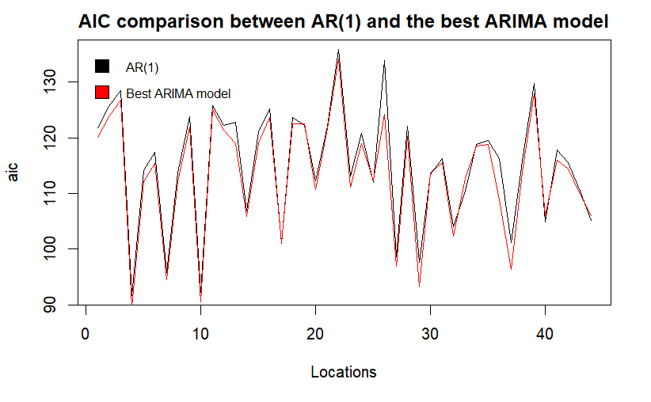

```r
legend("topleft", legend = c("AR(1)", "Best ARIMA model"), fill = c("black","red"), bty="n", cex=0.8)
```

As we can see from the AIC the model is very good wrt the others (Occam’s rasor).
Let’s forecast the value of Q2_2019 for each state. Our model now is:
$$y_{i,t} = \alpha_i*y_{i,t-1} + \epsilon_i$$
So we can use $\hat \alpha_i$:

```r
#2:
reduced_ts_no_mean_no_seas_2019Q2 <- coefficienti_AR1 *
                            reduced_ts_no_mean_no_seas["2019_Q1",]
aug_reduced_ts_no_mean_no_seas <- rbind(
  reduced_ts_no_mean_no_seas, "2019_Q2"=reduced_ts_no_mean_no_seas_2019Q2
)
```

Now it’s time “come back” to the seasonality to merge the datasets:

```r
aug_reduced_ts_no_mean <- rbind(
  reduced_ts_no_mean,
  "2019_Q2" = reduced_ts_no_mean_no_seas_2019Q2 + reduced_ts_no_mean["2018_Q2",]
)


complete_aug_reduced_ts_no_mean <- rbind(
  aug_reduced_ts_no_mean,
  ts_no_mean[seq(which(rownames(ts_no_mean)=="2019_Q3"),
                 which(rownames(ts_no_mean)=="2022_Q2")),]
)
```

Let’s look at some plots:

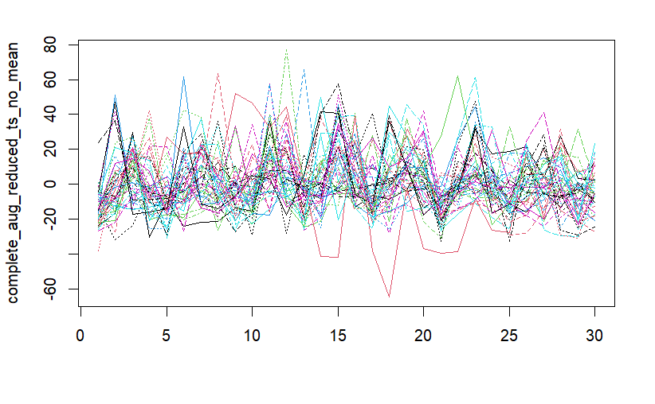

```r
matplot(complete_aug_reduced_ts_no_mean, type="l")
```

```r
n_plot = 3
plots= vector("list",n_plot*n_plot)
random_indexes = sample(1:p, n_plot*n_plot)
j = 1
for (i in random_indexes) {
  plots[[j]] = ggAcf(ts(complete_aug_reduced_ts_no_mean[,i]), lag.max = 30) + labs(title = locations[i])
  j = j+1
}
plot_ACF = do.call(grid.arrange, c(plots, ncol = n_plot, nrow = n_plot))
```

Let’s try to remove seasonality:

```r
complete_aug_reduced_ts_no_mean_no_seas <- diff(complete_aug_reduced_ts_no_mean, differences=1, lag=4)
n_plot = 3
plots= vector("list",n_plot*n_plot)
random_indexes = sample(1:p, n_plot*n_plot)
j = 1
for (i in random_indexes) {
  plots[[j]] = ggPacf(ts(complete_aug_reduced_ts_no_mean_no_seas[,i]), lag.max = 30) + labs(title = locations[i])
  j = j+1
}
plot_ACF = do.call(grid.arrange, c(plots, ncol = n_plot, nrow = n_plot))
```

Let’s see if an ARMA(1) would perform well:

```r
fitted_models_AR1 = vector(mode="list",length = p)
fitted_models_best = vector(mode="list",length = p)
coefficienti_AR1 = rep(0,p)
for(i in 1:p)
{
  fitted_models_AR1[[i]] = arima(complete_aug_reduced_ts_no_mean_no_seas[,i], order = c(1,0,0), include.mean = FALSE)
  coefficienti_AR1[i] = fitted_models_AR1[[i]]$coef
  fitted_models_best[[i]] = auto.arima(complete_aug_reduced_ts_no_mean_no_seas[,i])
}

aic_AR1 = rep(0,p)
aic_best = rep(0,p)
for(i in 1:p)
{
  aic_AR1[i] = fitted_models_AR1[[i]]$aic
  aic_best[i] = fitted_models_best[[i]]$aic
}
plot_aic = plot(aic_AR1, pch=19, xlab = "Locations", ylab="aic",type='l', main="AIC comparison between AR(1) and the best ARIMA model (no seasonality)")
points(aic_best, pch=19, col="red",type='l')
```

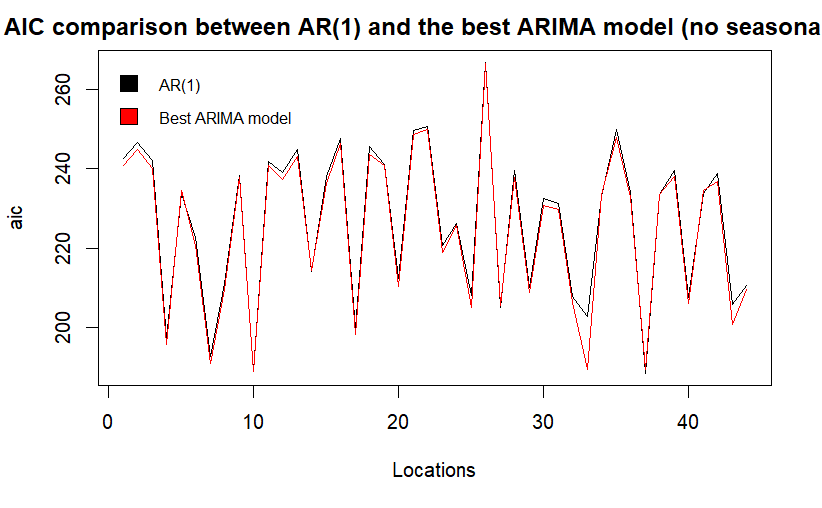

```r
legend("topleft", legend = c("AR(1)", "Best ARIMA model"), fill = c("black","red"), bty="n", cex=0.8)
```

Let’s compare the result with the original dataset (not augmented -> no 2019_Q2) without removing seas:

```r
fitted_models_AR1 = vector(mode="list",length = p)
fitted_models_best = vector(mode="list",length = p)
coefficienti_AR1 = rep(0,p)
for(i in 1:p)
{
  fitted_models_AR1[[i]] = arima(ts_no_mean[,i], order = c(1,0,0), include.mean = FALSE)
  coefficienti_AR1[i] = fitted_models_AR1[[i]]$coef
  fitted_models_best[[i]] = auto.arima(ts_no_mean[,i])
}

aic_AR1 = rep(0,p)
aic_best = rep(0,p)
for(i in 1:p)
{
  aic_AR1[i] = fitted_models_AR1[[i]]$aic
  aic_best[i] = fitted_models_best[[i]]$aic
}
plot_aic = plot(aic_AR1, pch=19, xlab = "Locations", ylab="aic",type='l', main="AIC comparison between AR(1) and the best ARIMA model")
points(aic_best, pch=19, col="red",type='l')
```

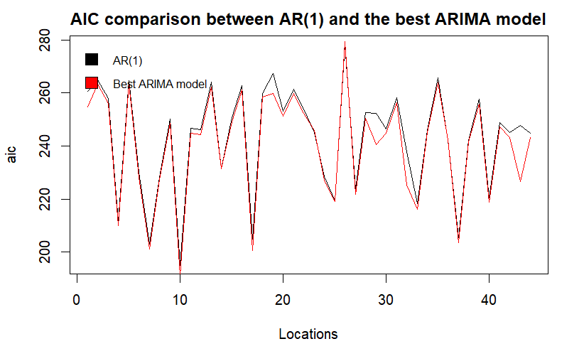

```r
legend("topleft", legend = c("AR(1)", "Best ARIMA model"), fill = c("black","red"), bty="n", cex=0.8)
```

As we can see, compaaring the two plots the detrended data are better to be modeled as AR(1), so let’s stick with them and cluster wrt them! Let’s do a frequentist estimate of the parameter we want to pass to the algorithm.

```r
  p = ncol(complete_aug_reduced_ts_no_mean_no_seas)
  fitted_models_AR1 = vector(mode="list",length = p)
  coefficienti_AR = rep(0,p)
  sigma_2_i = rep(0,p)

  for(i in 1:p)
  {
    fitted_models_AR1[[i]] = arima(complete_aug_reduced_ts_no_mean_no_seas[,i], order = c(1,0,0), include.mean = FALSE)
    coefficienti_AR[i] = fitted_models_AR1[[i]]$coef
    sigma_2_i[i] = fitted_models_AR1[[i]]$sigma2
  }

  # stimo i parametri delle prior
  ### rho_h ~ N(rho_0, sigma_2_h / lambda )
  rho_0 = mean(coefficienti_AR)
  sigma_2_avg = mean(sigma_2_i)
  var_rho_h = var(coefficienti_AR)
  lambda = (sigma_2_avg/var_rho_h)
  alpha = (sigma_2_avg)^2 / var(sigma_2_i) + 2
  beta = (alpha-1)*sigma_2_avg

  parametri = list(rho_0 = rho_0,
                   lambda = lambda,
                   alpha = alpha,
                   beta = beta)
```

Let’s save the output and datasets

```r
folder="data_output/"
write.table(t(complete_aug_reduced_ts_no_mean_no_seas),sep=",", row.names = FALSE, col.names=FALSE , file = paste(folder, "ts.csv", sep=""))
write.table(t(ts),sep=",", row.names = FALSE, col.names=FALSE , file = paste(folder, "ts_mean.csv", sep=""))
write.table(coord[,-3],sep=",", row.names = FALSE, col.names=FALSE , file = paste(folder, "coord.csv", sep=""))
```

Now, we can apply the library bayesmix to cluster our data.

Import the output of bayesmix:

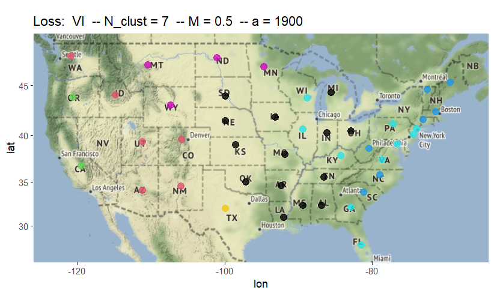

```r
source("utils_e/plot_clustering.R")

num_clust = read.csv("data_output/numclust.csv", header = FALSE)
names(num_clust)="n"

partitions = read.csv("data_output/clustering.csv", header = FALSE)

M <- 0.5
a <- 1900
label <- F
ob6 = plot_clustering(partitions, coord[,-3], "VI" ,M, a, ts_varroa[,-1], label = label)
ob6$plot
```

```r
# questo lo faccio quando ho poi tutto bello pronto il prog di bayesian così ci metto di -
# assumo di avere vettore cluster allocation (simulo 4 cluster) per i 46 stati
set.seed(123)
cluster_alloc <- ob6$best_clus
```

Now, we can use a functional approach on loss data in order to see if there are differences for the medians of the groups. Let’s prepare tha dataset transforming it functionally

```r
length_ts <- dim(ts_varroa)[2]-1
grid <- seq(1,length_ts, by=1)

fd_varroa <- fData(grid,ts_varroa[,-1])
fd_tempmin <- fData(grid, ts_varroa[,-1])
```

JUST to *explore* the result obtained from let’s plot them coloring wrt the cluster (it’s wanted to see that they are separated in some sense)

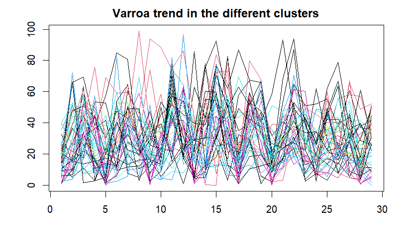

```r
plot(fd_varroa, col=as.numeric(cluster_alloc), main="Varroa trend in the different clusters") #aggungere in base a cluster
```

```r
#plot(fd_tempmin, col=as.numeric(cluster_alloc))
#f_data <- append_fData(,2)
```

Let’s prepare the dataset for the colony losses (USO PCT ORA):

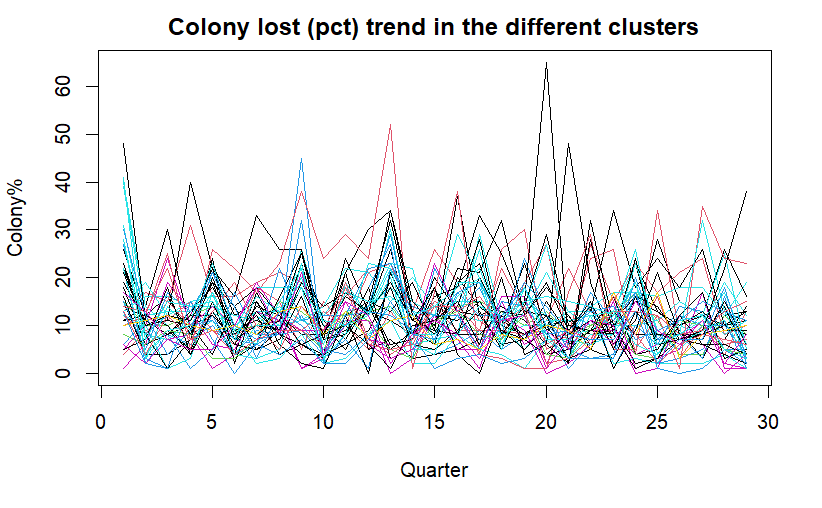

```r
data_colonylost <- data[,c(1,2,3,7)]
ts_colonylost <- data_colonylost %>% tidyr::pivot_wider(
  names_from = c("year", "months"),
  values_from = colony_lost_pct, ####se vui % cambia qua
  values_fill = NULL
)

fd_colonylost <- fData(grid,ts_colonylost[,-1])
plot(fd_colonylost, col=as.numeric(cluster_alloc), main="Colony lost (pct) trend in the different clusters", xlab = "Quarter", ylab = "Colony%")
```

Let’s compute the median of the clusters (using modified band depth) and superimpose them on the plot:

```r
clus1 <- which(cluster_alloc==1)
clus2 <- which(cluster_alloc==2)
clus3 <- which(cluster_alloc==3)
clus4 <- which(cluster_alloc==4)
clus5 <- which(cluster_alloc==5)
clus6 <- which(cluster_alloc==6)



median1 <- median_fData(fd_colonylost[clus1,], type="MBD")
median2 <- median_fData(fd_colonylost[clus2,], type="MBD")
median3 <- median_fData(fd_colonylost[clus3,], type="MBD")
median4 <- median_fData(fd_colonylost[clus4,], type="MBD")
median5 <- median_fData(fd_colonylost[clus5,], type="MBD")
median6 <- median_fData(fd_colonylost[clus6,], type="MBD")


plot(fd_colonylost, col=as.numeric(cluster_alloc), main="Colony lost (pct) trend in the different clusters", xlab = "Quarter", ylab = "Colony%")
lines(grid, median1$value, col=1, lwd = 2)
```

```r
lines(grid, median2$value, col=2, lwd = 2)
lines(grid, median3$value, col=3, lwd = 2)
```

```r
lines(grid, median4$value, col=4, lwd = 2)
lines(grid, median4$value, col=5, lwd = 2)
```

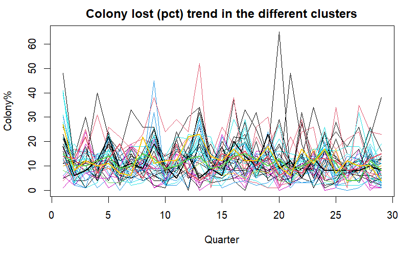

```r
lines(grid, median4$value, col=6, lwd = 2)
lines(grid, median4$value, col=7, lwd = 2)
```

```r
NA
NA
```

## Spot if we have outliers inside the group: #farlo in base a quanti gruppi troviamo

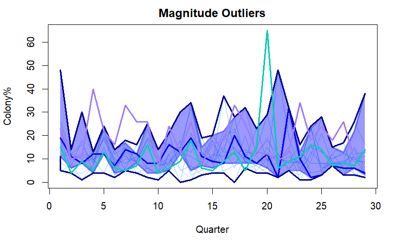

```r
bxplot = invisible(fbplot(fd_colonylost[clus1,], main = "Magnitude Outliers", xlab = "Quarter", ylab = "Colony%"))
```

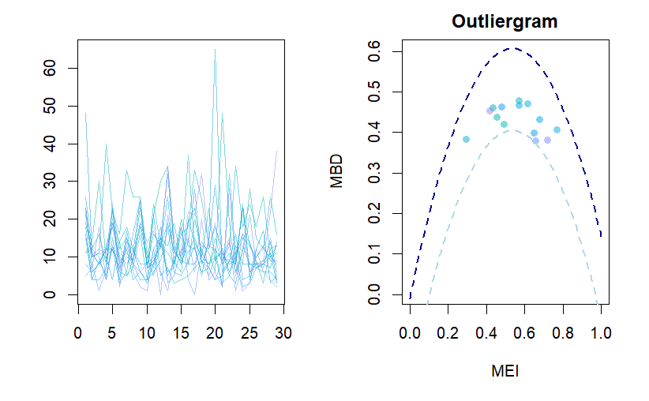

```r
out_funct <- outliergram(fd_colonylost[clus1,])
```

```r
out_funct$ID_outliers
```

```
integer(0)
```

If it is necessary we can remove outliers…

# Test difference between clusters

Now that we have a cluster wrt to Varroa, we want to test if the distribution of the colony_lost differ between the cluster. We test it using the functional medians, i.e: H0 : med(c_1)=med(c_2)=…=med(c_i) vs H1: H0^c

Let’s do a pairwise test first:  
## Clus 1-2

```r
x1_fd <- fd_colonylost[clus1,] #
x2_fd <- fd_colonylost[clus2,] #
medianx1 <- median1 #
medianx2 <- median2 #

datapooled=append_fData(x1_fd,x2_fd)

n=datapooled$N
n1=x1_fd$N
n2=x2_fd$N

meandiff = medianx1$values - medianx2$values
#plot(grid,meandiff,type = 'l')
T0=(sum(abs(meandiff)))
#And, Knowing that under H0 the two groups of curves are IID,
# my likelihood-invariant permutation scheme is of course label permutation, so:
B <- 1000
set.seed(2023)
T0_perm=numeric(B)

pb = progress::progress_bar$new(total = B,
                                format = " Processing [:bar] :percent eta: :eta")
for(b in 1:B){
  permutazione <- sample(n)
  datapooled_perm=datapooled[permutazione,]
  perm_1 = datapooled_perm[1:n1,]
  perm_2 = datapooled_perm[(n1+1):n,]
  #se funzionale
  meandiff_p =median_fData(perm_1,type='MBD')$values-median_fData(perm_2,type='MBD')$values
  T0_perm[b]=(sum(abs(meandiff_p))) #set
  pb$tick()
}
```

```
 Processing [>---------------------------]   3% eta:  6s
 Processing [>---------------------------]   4% eta:  6s
 Processing [>---------------------------]   5% eta:  6s
 Processing [=>--------------------------]   5% eta:  6s
 Processing [=>--------------------------]   6% eta:  6s
 Processing [=>--------------------------]   7% eta:  6s
 Processing [=>--------------------------]   8% eta:  6s
 Processing [=>--------------------------]   9% eta:  6s
 Processing [==>-------------------------]   9% eta:  6s
 Processing [==>-------------------------]  10% eta:  6s
 Processing [==>-------------------------]  11% eta:  6s
 Processing [==>-------------------------]  12% eta:  6s
 Processing [===>------------------------]  12% eta:  6s
 Processing [===>------------------------]  13% eta:  6s
 Processing [===>------------------------]  14% eta:  6s
 Processing [===>------------------------]  15% eta:  6s
 Processing [===>------------------------]  16% eta:  6s
 Processing [====>-----------------------]  16% eta:  6s
 Processing [====>-----------------------]  17% eta:  6s
 Processing [====>-----------------------]  18% eta:  6s
 Processing [====>-----------------------]  19% eta:  6s
 Processing [====>-----------------------]  20% eta:  6s
 Processing [=====>----------------------]  20% eta:  6s
 Processing [=====>----------------------]  21% eta:  6s
 Processing [=====>----------------------]  22% eta:  6s
 Processing [=====>----------------------]  23% eta:  6s
 Processing [======>---------------------]  23% eta:  6s
 Processing [======>---------------------]  24% eta:  6s
 Processing [======>---------------------]  25% eta:  6s
 Processing [======>---------------------]  25% eta:  5s
 Processing [======>---------------------]  26% eta:  5s
 Processing [======>---------------------]  27% eta:  5s
 Processing [=======>--------------------]  27% eta:  5s
 Processing [=======>--------------------]  28% eta:  5s
 Processing [=======>--------------------]  29% eta:  5s
 Processing [=======>--------------------]  30% eta:  5s
 Processing [========>-------------------]  30% eta:  5s
 Processing [========>-------------------]  31% eta:  5s
 Processing [========>-------------------]  32% eta:  5s
 Processing [========>-------------------]  33% eta:  5s
```

[output cut: 75 more lines]

```
 Processing [========================>---]  90% eta:  1s
 Processing [========================>---]  91% eta:  1s
 Processing [=========================>--]  91% eta:  1s
 Processing [=========================>--]  92% eta:  1s
 Processing [=========================>--]  93% eta:  1s
 Processing [=========================>--]  94% eta:  0s
 Processing [=========================>--]  95% eta:  0s
 Processing [==========================>-]  95% eta:  0s
 Processing [==========================>-]  96% eta:  0s
 Processing [==========================>-]  97% eta:  0s
 Processing [==========================>-]  98% eta:  0s
 Processing [===========================>]  98% eta:  0s
 Processing [===========================>]  99% eta:  0s
 Processing [===========================>] 100% eta:  0s
 Processing [============================] 100% eta:  0s
```

Let’s see the results:

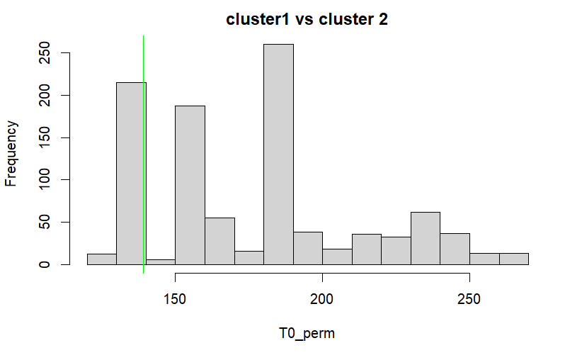

```r
pval = sum(T0_perm >= T0)/B
hist(T0_perm, main = "cluster1 vs cluster 2") #
abline(v=T0,col='green')
```

```r
print(paste("pvalue for test cluster 1 vs cluster 2 is :", pval)) #
```

```
[1] "pvalue for test cluster 1 vs cluster 2 is : 0.933"
```

## Clus 1-3

```r
x1_fd <- fd_colonylost[clus1,]
x2_fd <- fd_colonylost[clus3,]
medianx1 <- median1
medianx2 <- median3

datapooled=append_fData(x1_fd,x2_fd)

n=datapooled$N
n1=x1_fd$N
n2=x2_fd$N

meandiff = medianx1$values - medianx2$values
#plot(grid,meandiff,type = 'l')
T0=(sum(abs(meandiff)))
#And, Knowing that under H0 the two groups of curves are IID,
# my likelihood-invariant permutation scheme is of course label permutation, so:
B <- 1000
set.seed(2023)
T0_perm=numeric(B)

pb = progress::progress_bar$new(total = B,
                                format = " Processing [:bar] :percent eta: :eta")
for(b in 1:B){
  permutazione <- sample(n)
  datapooled_perm=datapooled[permutazione,]
  perm_1 = datapooled_perm[1:n1,]
  perm_2 = datapooled_perm[(n1+1):n,]
  #se funzionale
  meandiff_p =median_fData(perm_1,type='MBD')$values-median_fData(perm_2,type='MBD')$values
  T0_perm[b]=(sum(abs(meandiff_p))) #set
  pb$tick()
}
```

```
 Processing [>---------------------------]   3% eta:  7s
 Processing [>---------------------------]   3% eta:  8s
 Processing [>---------------------------]   3% eta: 10s
 Processing [>---------------------------]   4% eta: 10s
 Processing [>---------------------------]   5% eta: 10s
 Processing [>---------------------------]   5% eta:  9s
 Processing [=>--------------------------]   5% eta:  9s
 Processing [=>--------------------------]   6% eta:  9s
 Processing [=>--------------------------]   7% eta:  9s
 Processing [=>--------------------------]   8% eta:  9s
 Processing [=>--------------------------]   8% eta:  8s
 Processing [=>--------------------------]   9% eta:  8s
 Processing [==>-------------------------]   9% eta:  8s
 Processing [==>-------------------------]  10% eta:  8s
 Processing [==>-------------------------]  11% eta:  8s
 Processing [==>-------------------------]  12% eta:  8s
 Processing [==>-------------------------]  12% eta:  7s
 Processing [==>-------------------------]  12% eta:  8s
 Processing [==>-------------------------]  12% eta:  7s
 Processing [===>------------------------]  12% eta:  7s
 Processing [===>------------------------]  13% eta:  7s
 Processing [===>------------------------]  14% eta:  7s
 Processing [===>------------------------]  15% eta:  7s
 Processing [===>------------------------]  16% eta:  7s
 Processing [====>-----------------------]  16% eta:  7s
 Processing [====>-----------------------]  17% eta:  7s
 Processing [====>-----------------------]  18% eta:  7s
 Processing [====>-----------------------]  19% eta:  7s
 Processing [====>-----------------------]  20% eta:  7s
 Processing [=====>----------------------]  20% eta:  7s
 Processing [=====>----------------------]  21% eta:  7s
 Processing [=====>----------------------]  21% eta:  6s
 Processing [=====>----------------------]  22% eta:  6s
 Processing [=====>----------------------]  23% eta:  6s
 Processing [======>---------------------]  23% eta:  6s
 Processing [======>---------------------]  24% eta:  6s
 Processing [======>---------------------]  25% eta:  6s
 Processing [======>---------------------]  26% eta:  6s
 Processing [======>---------------------]  27% eta:  6s
 Processing [=======>--------------------]  27% eta:  6s
```

[output cut: 84 more lines]

```
 Processing [========================>---]  91% eta:  1s
 Processing [=========================>--]  91% eta:  1s
 Processing [=========================>--]  92% eta:  1s
 Processing [=========================>--]  93% eta:  1s
 Processing [=========================>--]  94% eta:  1s
 Processing [=========================>--]  94% eta:  0s
 Processing [=========================>--]  95% eta:  0s
 Processing [==========================>-]  95% eta:  0s
 Processing [==========================>-]  96% eta:  0s
 Processing [==========================>-]  97% eta:  0s
 Processing [==========================>-]  98% eta:  0s
 Processing [===========================>]  98% eta:  0s
 Processing [===========================>]  99% eta:  0s
 Processing [===========================>] 100% eta:  0s
 Processing [============================] 100% eta:  0s
```

Let’s see the results:

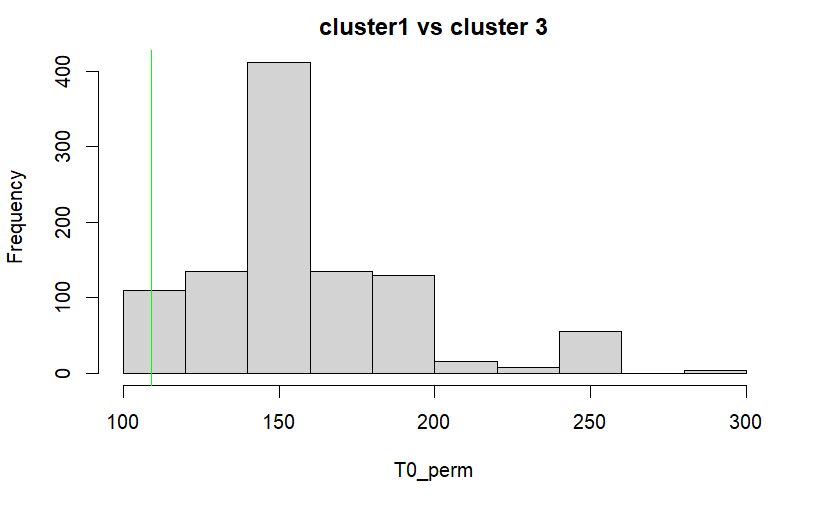

```r
pval = sum(T0_perm >= T0)/B
hist(T0_perm, main = "cluster1 vs cluster 3")
abline(v=T0,col='green')
```

```r
print(paste("pvalue for test cluster 1 vs cluster 3 is :", pval)) #
```

```
[1] "pvalue for test cluster 1 vs cluster 3 is : 1"
```

## Cluster 1-4

```r
x1_fd <- fd_colonylost[clus1,]
x2_fd <- fd_colonylost[clus4,]
medianx1 <- median1
medianx2 <- median4

datapooled=append_fData(x1_fd,x2_fd)

n=datapooled$N
n1=x1_fd$N
n2=x2_fd$N

meandiff = medianx1$values - medianx2$values
#plot(grid,meandiff,type = 'l')
T0=(sum(abs(meandiff)))
#And, Knowing that under H0 the two groups of curves are IID,
# my likelihood-invariant permutation scheme is of course label permutation, so:
B <- 1000
set.seed(2023)
T0_perm=numeric(B)

pb = progress::progress_bar$new(total = B,
                                format = " Processing [:bar] :percent eta: :eta")
for(b in 1:B){
  permutazione <- sample(n)
  datapooled_perm=datapooled[permutazione,]
  perm_1 = datapooled_perm[1:n1,]
  perm_2 = datapooled_perm[(n1+1):n,]
  #se funzionale
  meandiff_p =median_fData(perm_1,type='MBD')$values-median_fData(perm_2,type='MBD')$values
  T0_perm[b]=(sum(abs(meandiff_p))) #set
  pb$tick()
}
```

```
 Processing [>---------------------------]   3% eta:  7s
 Processing [>---------------------------]   3% eta:  8s
 Processing [>---------------------------]   4% eta:  8s
 Processing [>---------------------------]   5% eta:  8s
 Processing [=>--------------------------]   5% eta:  8s
 Processing [=>--------------------------]   6% eta:  8s
 Processing [=>--------------------------]   7% eta:  8s
 Processing [=>--------------------------]   8% eta:  8s
 Processing [=>--------------------------]   9% eta:  8s
 Processing [==>-------------------------]   9% eta:  8s
 Processing [==>-------------------------]   9% eta:  7s
 Processing [==>-------------------------]  10% eta:  7s
 Processing [==>-------------------------]  11% eta:  7s
 Processing [==>-------------------------]  12% eta:  7s
 Processing [===>------------------------]  12% eta:  7s
 Processing [===>------------------------]  13% eta:  7s
 Processing [===>------------------------]  14% eta:  7s
 Processing [===>------------------------]  15% eta:  7s
 Processing [===>------------------------]  16% eta:  7s
 Processing [====>-----------------------]  16% eta:  7s
 Processing [====>-----------------------]  17% eta:  7s
 Processing [====>-----------------------]  17% eta:  6s
 Processing [====>-----------------------]  18% eta:  6s
 Processing [====>-----------------------]  19% eta:  6s
 Processing [====>-----------------------]  20% eta:  6s
 Processing [=====>----------------------]  20% eta:  6s
 Processing [=====>----------------------]  21% eta:  6s
 Processing [=====>----------------------]  22% eta:  6s
 Processing [=====>----------------------]  23% eta:  6s
 Processing [======>---------------------]  23% eta:  6s
 Processing [======>---------------------]  24% eta:  6s
 Processing [======>---------------------]  25% eta:  6s
 Processing [======>---------------------]  26% eta:  6s
 Processing [======>---------------------]  27% eta:  6s
 Processing [=======>--------------------]  27% eta:  6s
 Processing [=======>--------------------]  28% eta:  6s
 Processing [=======>--------------------]  28% eta:  5s
 Processing [=======>--------------------]  29% eta:  5s
 Processing [=======>--------------------]  30% eta:  5s
 Processing [========>-------------------]  30% eta:  5s
```

[output cut: 79 more lines]

```
 Processing [========================>---]  91% eta:  1s
 Processing [=========================>--]  91% eta:  1s
 Processing [=========================>--]  92% eta:  1s
 Processing [=========================>--]  93% eta:  1s
 Processing [=========================>--]  94% eta:  1s
 Processing [=========================>--]  94% eta:  0s
 Processing [=========================>--]  95% eta:  0s
 Processing [==========================>-]  95% eta:  0s
 Processing [==========================>-]  96% eta:  0s
 Processing [==========================>-]  97% eta:  0s
 Processing [==========================>-]  98% eta:  0s
 Processing [===========================>]  98% eta:  0s
 Processing [===========================>]  99% eta:  0s
 Processing [===========================>] 100% eta:  0s
 Processing [============================] 100% eta:  0s
```

Let’s see the results:

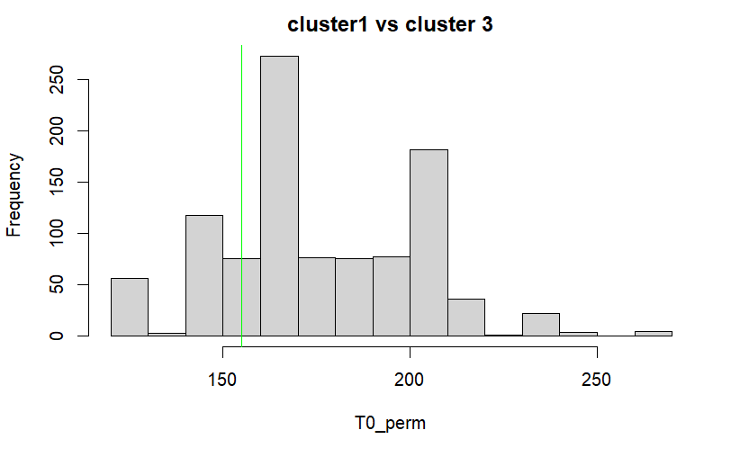

```r
pval = sum(T0_perm >= T0)/B
hist(T0_perm, main = "cluster1 vs cluster 3")
abline(v=T0,col='green')
```

```r
print(paste("pvalue for test cluster 1 vs cluster 4 is :", pval)) #
```

```
[1] "pvalue for test cluster 1 vs cluster 4 is : 0.811"
```

#Cluseter 1-5

```r
x1_fd <- fd_colonylost[clus1,]
x2_fd <- fd_colonylost[clus5,]
medianx1 <- median1
medianx2 <- median5

datapooled=append_fData(x1_fd,x2_fd)

n=datapooled$N
n1=x1_fd$N
n2=x2_fd$N

meandiff = medianx1$values - medianx2$values
#plot(grid,meandiff,type = 'l')
T0=(sum(abs(meandiff)))
#And, Knowing that under H0 the two groups of curves are IID,
# my likelihood-invariant permutation scheme is of course label permutation, so:
B <- 1000
set.seed(2023)
T0_perm=numeric(B)

pb = progress::progress_bar$new(total = B,
                                format = " Processing [:bar] :percent eta: :eta")
for(b in 1:B){
  permutazione <- sample(n)
  datapooled_perm=datapooled[permutazione,]
  perm_1 = datapooled_perm[1:n1,]
  perm_2 = datapooled_perm[(n1+1):n,]
  #se funzionale
  meandiff_p =median_fData(perm_1,type='MBD')$values-median_fData(perm_2,type='MBD')$values
  T0_perm[b]=(sum(abs(meandiff_p))) #set
  pb$tick()
}
```

```
 Processing [>---------------------------]   3% eta:  8s
 Processing [>---------------------------]   4% eta:  8s
 Processing [>---------------------------]   5% eta:  8s
 Processing [=>--------------------------]   5% eta:  8s
 Processing [=>--------------------------]   6% eta:  8s
 Processing [=>--------------------------]   7% eta:  8s
 Processing [=>--------------------------]   8% eta:  8s
 Processing [=>--------------------------]   9% eta:  8s
 Processing [==>-------------------------]   9% eta:  8s
 Processing [==>-------------------------]  10% eta:  8s
 Processing [==>-------------------------]  10% eta:  7s
 Processing [==>-------------------------]  11% eta:  7s
 Processing [==>-------------------------]  12% eta:  7s
 Processing [===>------------------------]  12% eta:  7s
 Processing [===>------------------------]  13% eta:  7s
 Processing [===>------------------------]  14% eta:  7s
 Processing [===>------------------------]  15% eta:  7s
 Processing [===>------------------------]  16% eta:  7s
 Processing [====>-----------------------]  16% eta:  7s
 Processing [====>-----------------------]  17% eta:  7s
 Processing [====>-----------------------]  18% eta:  7s
 Processing [====>-----------------------]  18% eta:  6s
 Processing [====>-----------------------]  19% eta:  6s
 Processing [====>-----------------------]  20% eta:  6s
 Processing [=====>----------------------]  20% eta:  6s
 Processing [=====>----------------------]  21% eta:  6s
 Processing [=====>----------------------]  22% eta:  6s
 Processing [=====>----------------------]  23% eta:  6s
 Processing [======>---------------------]  23% eta:  6s
 Processing [======>---------------------]  24% eta:  6s
 Processing [======>---------------------]  25% eta:  6s
 Processing [======>---------------------]  26% eta:  6s
 Processing [======>---------------------]  27% eta:  6s
 Processing [=======>--------------------]  27% eta:  6s
 Processing [=======>--------------------]  28% eta:  6s
 Processing [=======>--------------------]  29% eta:  5s
 Processing [=======>--------------------]  30% eta:  5s
 Processing [========>-------------------]  30% eta:  5s
 Processing [========>-------------------]  31% eta:  5s
 Processing [========>-------------------]  32% eta:  5s
```

[output cut: 77 more lines]

```
 Processing [========================>---]  91% eta:  1s
 Processing [=========================>--]  91% eta:  1s
 Processing [=========================>--]  92% eta:  1s
 Processing [=========================>--]  93% eta:  1s
 Processing [=========================>--]  94% eta:  1s
 Processing [=========================>--]  94% eta:  0s
 Processing [=========================>--]  95% eta:  0s
 Processing [==========================>-]  95% eta:  0s
 Processing [==========================>-]  96% eta:  0s
 Processing [==========================>-]  97% eta:  0s
 Processing [==========================>-]  98% eta:  0s
 Processing [===========================>]  98% eta:  0s
 Processing [===========================>]  99% eta:  0s
 Processing [===========================>] 100% eta:  0s
 Processing [============================] 100% eta:  0s
```

Let’s see the results:

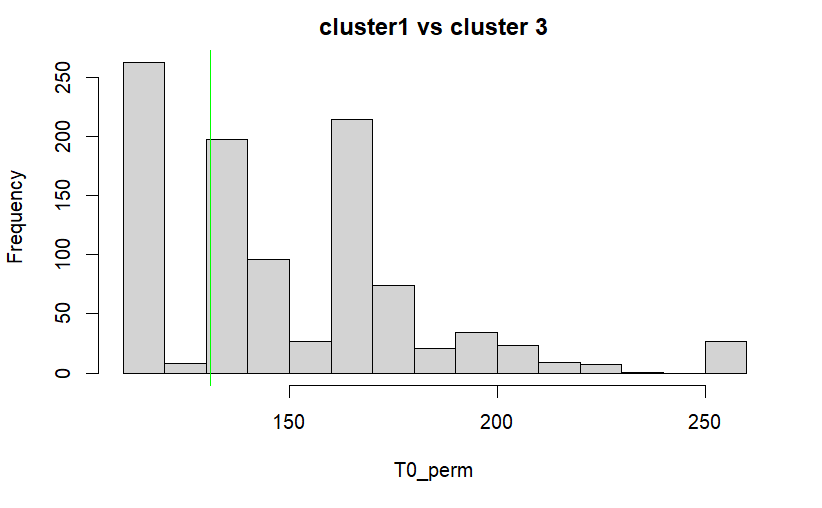

```r
pval = sum(T0_perm >= T0)/B
hist(T0_perm, main = "cluster1 vs cluster 3")
abline(v=T0,col='green')
```

```r
print(paste("pvalue for test cluster 1 vs cluster 5 is :", pval)) #
```

```
[1] "pvalue for test cluster 1 vs cluster 5 is : 0.73"
```

# Clus 1-6

```r
x1_fd <- fd_colonylost[clus1,]
x2_fd <- fd_colonylost[clus6,]
medianx1 <- median1
medianx2 <- median6

datapooled=append_fData(x1_fd,x2_fd)

n=datapooled$N
n1=x1_fd$N
n2=x2_fd$N

meandiff = medianx1$values - medianx2$values
#plot(grid,meandiff,type = 'l')
T0=(sum(abs(meandiff)))
#And, Knowing that under H0 the two groups of curves are IID,
# my likelihood-invariant permutation scheme is of course label permutation, so:
B <- 1000
set.seed(2023)
T0_perm=numeric(B)

pb = progress::progress_bar$new(total = B,
                                format = " Processing [:bar] :percent eta: :eta")
for(b in 1:B){
  permutazione <- sample(n)
  datapooled_perm=datapooled[permutazione,]
  perm_1 = datapooled_perm[1:n1,]
  perm_2 = datapooled_perm[(n1+1):n,]
  #se funzionale
  meandiff_p =median_fData(perm_1,type='MBD')$values-median_fData(perm_2,type='MBD')$values
  T0_perm[b]=(sum(abs(meandiff_p))) #set
  pb$tick()
}
```

```
 Processing [>---------------------------]   3% eta:  7s
 Processing [>---------------------------]   3% eta:  8s
 Processing [>---------------------------]   4% eta:  8s
 Processing [>---------------------------]   5% eta:  8s
 Processing [=>--------------------------]   5% eta:  8s
 Processing [=>--------------------------]   6% eta:  8s
 Processing [=>--------------------------]   7% eta:  8s
 Processing [=>--------------------------]   8% eta:  8s
 Processing [=>--------------------------]   8% eta:  7s
 Processing [=>--------------------------]   9% eta:  7s
 Processing [==>-------------------------]   9% eta:  7s
 Processing [==>-------------------------]  10% eta:  7s
 Processing [==>-------------------------]  11% eta:  7s
 Processing [==>-------------------------]  12% eta:  7s
 Processing [===>------------------------]  12% eta:  7s
 Processing [===>------------------------]  13% eta:  7s
 Processing [===>------------------------]  14% eta:  7s
 Processing [===>------------------------]  15% eta:  7s
 Processing [===>------------------------]  16% eta:  7s
 Processing [====>-----------------------]  16% eta:  7s
 Processing [====>-----------------------]  17% eta:  6s
 Processing [====>-----------------------]  18% eta:  6s
 Processing [====>-----------------------]  19% eta:  6s
 Processing [====>-----------------------]  20% eta:  6s
 Processing [=====>----------------------]  20% eta:  6s
 Processing [=====>----------------------]  21% eta:  6s
 Processing [=====>----------------------]  22% eta:  6s
 Processing [=====>----------------------]  23% eta:  6s
 Processing [======>---------------------]  23% eta:  6s
 Processing [======>---------------------]  24% eta:  6s
 Processing [======>---------------------]  25% eta:  6s
 Processing [======>---------------------]  26% eta:  6s
 Processing [======>---------------------]  27% eta:  6s
 Processing [=======>--------------------]  27% eta:  6s
 Processing [=======>--------------------]  28% eta:  6s
 Processing [=======>--------------------]  28% eta:  5s
 Processing [=======>--------------------]  29% eta:  5s
 Processing [=======>--------------------]  30% eta:  5s
 Processing [========>-------------------]  30% eta:  5s
 Processing [========>-------------------]  31% eta:  5s
```

[output cut: 79 more lines]

```
 Processing [========================>---]  91% eta:  1s
 Processing [=========================>--]  91% eta:  1s
 Processing [=========================>--]  92% eta:  1s
 Processing [=========================>--]  93% eta:  1s
 Processing [=========================>--]  94% eta:  1s
 Processing [=========================>--]  94% eta:  0s
 Processing [=========================>--]  95% eta:  0s
 Processing [==========================>-]  95% eta:  0s
 Processing [==========================>-]  96% eta:  0s
 Processing [==========================>-]  97% eta:  0s
 Processing [==========================>-]  98% eta:  0s
 Processing [===========================>]  98% eta:  0s
 Processing [===========================>]  99% eta:  0s
 Processing [===========================>] 100% eta:  0s
 Processing [============================] 100% eta:  0s
```

Let’s see the results:

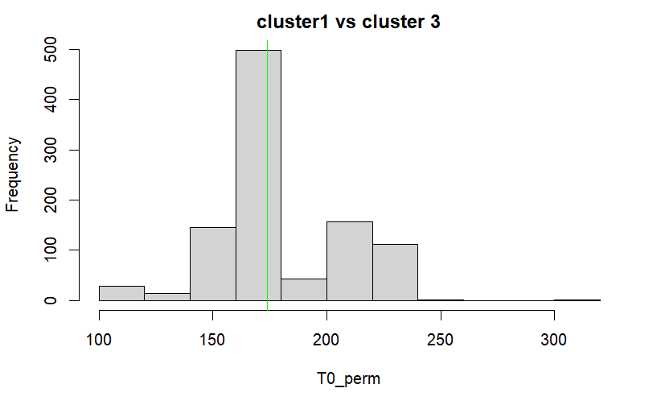

```r
pval = sum(T0_perm >= T0)/B
hist(T0_perm, main = "cluster1 vs cluster 3")
abline(v=T0,col='green')
```

```r
print(paste("pvalue for test cluster 1 vs cluster 6 is :", pval)) #
```

```
[1] "pvalue for test cluster 1 vs cluster 6 is : 0.392"
```

#Cluster 2-3

```r
x1_fd <- fd_colonylost[clus2,]
x2_fd <- fd_colonylost[clus3,]
medianx1 <- median2
medianx2 <- median3

datapooled=append_fData(x1_fd,x2_fd)

n=datapooled$N
n1=x1_fd$N
n2=x2_fd$N

meandiff = medianx1$values - medianx2$values
#plot(grid,meandiff,type = 'l')
T0=(sum(abs(meandiff)))
#And, Knowing that under H0 the two groups of curves are IID,
# my likelihood-invariant permutation scheme is of course label permutation, so:
B <- 1000
set.seed(2023)
T0_perm=numeric(B)

pb = progress::progress_bar$new(total = B,
                                format = " Processing [:bar] :percent eta: :eta")
for(b in 1:B){
  permutazione <- sample(n)
  datapooled_perm=datapooled[permutazione,]
  perm_1 = datapooled_perm[1:n1,]
  perm_2 = datapooled_perm[(n1+1):n,]
  #se funzionale
  meandiff_p =median_fData(perm_1,type='MBD')$values-median_fData(perm_2,type='MBD')$values
  T0_perm[b]=(sum(abs(meandiff_p))) #set
  pb$tick()
}
```

```
 Processing [>---------------------------]   3% eta:  6s
 Processing [>---------------------------]   4% eta:  6s
 Processing [>---------------------------]   5% eta:  6s
 Processing [=>--------------------------]   5% eta:  6s
 Processing [=>--------------------------]   6% eta:  6s
 Processing [=>--------------------------]   7% eta:  6s
 Processing [=>--------------------------]   8% eta:  6s
 Processing [=>--------------------------]   9% eta:  6s
 Processing [==>-------------------------]   9% eta:  6s
 Processing [==>-------------------------]  10% eta:  6s
 Processing [==>-------------------------]  11% eta:  6s
 Processing [==>-------------------------]  12% eta:  6s
 Processing [===>------------------------]  12% eta:  6s
 Processing [===>------------------------]  13% eta:  6s
 Processing [===>------------------------]  14% eta:  6s
 Processing [===>------------------------]  15% eta:  6s
 Processing [===>------------------------]  16% eta:  6s
 Processing [====>-----------------------]  16% eta:  6s
 Processing [====>-----------------------]  17% eta:  6s
 Processing [====>-----------------------]  18% eta:  6s
 Processing [====>-----------------------]  19% eta:  6s
 Processing [====>-----------------------]  20% eta:  6s
 Processing [=====>----------------------]  20% eta:  6s
 Processing [=====>----------------------]  21% eta:  6s
 Processing [=====>----------------------]  21% eta:  5s
 Processing [=====>----------------------]  22% eta:  5s
 Processing [=====>----------------------]  23% eta:  5s
 Processing [======>---------------------]  23% eta:  5s
 Processing [======>---------------------]  24% eta:  5s
 Processing [======>---------------------]  25% eta:  5s
 Processing [======>---------------------]  26% eta:  5s
 Processing [======>---------------------]  27% eta:  5s
 Processing [=======>--------------------]  27% eta:  5s
 Processing [=======>--------------------]  28% eta:  5s
 Processing [=======>--------------------]  29% eta:  5s
 Processing [=======>--------------------]  30% eta:  5s
 Processing [========>-------------------]  30% eta:  5s
 Processing [========>-------------------]  31% eta:  5s
 Processing [========>-------------------]  32% eta:  5s
 Processing [========>-------------------]  33% eta:  5s
```

[output cut: 76 more lines]

```
 Processing [========================>---]  90% eta:  1s
 Processing [========================>---]  91% eta:  1s
 Processing [=========================>--]  91% eta:  1s
 Processing [=========================>--]  92% eta:  1s
 Processing [=========================>--]  93% eta:  1s
 Processing [=========================>--]  94% eta:  0s
 Processing [=========================>--]  95% eta:  0s
 Processing [==========================>-]  95% eta:  0s
 Processing [==========================>-]  96% eta:  0s
 Processing [==========================>-]  97% eta:  0s
 Processing [==========================>-]  98% eta:  0s
 Processing [===========================>]  98% eta:  0s
 Processing [===========================>]  99% eta:  0s
 Processing [===========================>] 100% eta:  0s
 Processing [============================] 100% eta:  0s
```

Let’s see the results:

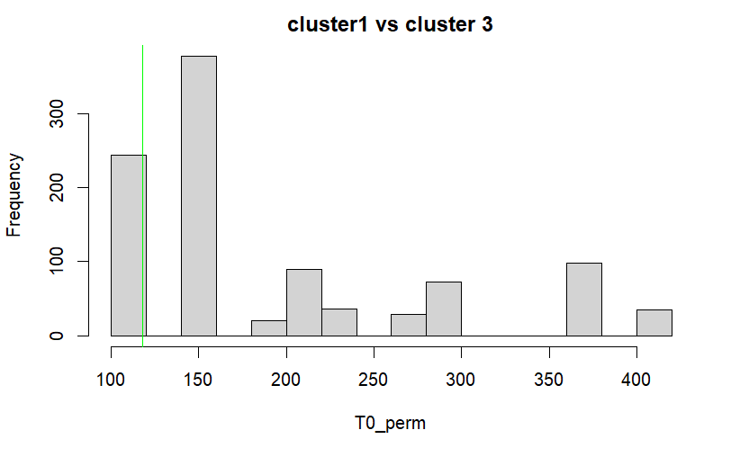

```r
pval = sum(T0_perm >= T0)/B
hist(T0_perm, main = "cluster1 vs cluster 3")
abline(v=T0,col='green')
```

```r
print(paste("pvalue for test cluster 2 vs cluster 3 is :", pval)) #
```

```
[1] "pvalue for test cluster 2 vs cluster 3 is : 1"
```

#Cluster 2-4

```r
x1_fd <- fd_colonylost[clus2,]
x2_fd <- fd_colonylost[clus4,]
medianx1 <- median2
medianx2 <- median4

datapooled=append_fData(x1_fd,x2_fd)

n=datapooled$N
n1=x1_fd$N
n2=x2_fd$N

meandiff = medianx1$values - medianx2$values
#plot(grid,meandiff,type = 'l')
T0=(sum(abs(meandiff)))
#And, Knowing that under H0 the two groups of curves are IID,
# my likelihood-invariant permutation scheme is of course label permutation, so:
B <- 1000
set.seed(2023)
T0_perm=numeric(B)

pb = progress::progress_bar$new(total = B,
                                format = " Processing [:bar] :percent eta: :eta")
for(b in 1:B){
  permutazione <- sample(n)
  datapooled_perm=datapooled[permutazione,]
  perm_1 = datapooled_perm[1:n1,]
  perm_2 = datapooled_perm[(n1+1):n,]
  #se funzionale
  meandiff_p =median_fData(perm_1,type='MBD')$values-median_fData(perm_2,type='MBD')$values
  T0_perm[b]=(sum(abs(meandiff_p))) #set
  pb$tick()
}
```

```
 Processing [>---------------------------]   3% eta:  6s
 Processing [>---------------------------]   4% eta:  6s
 Processing [>---------------------------]   5% eta:  6s
 Processing [>---------------------------]   5% eta:  7s
 Processing [=>--------------------------]   5% eta:  7s
 Processing [=>--------------------------]   6% eta:  7s
 Processing [=>--------------------------]   7% eta:  7s
 Processing [=>--------------------------]   7% eta:  6s
 Processing [=>--------------------------]   8% eta:  7s
 Processing [=>--------------------------]   8% eta:  6s
 Processing [=>--------------------------]   8% eta:  7s
 Processing [=>--------------------------]   8% eta:  6s
 Processing [=>--------------------------]   9% eta:  6s
 Processing [==>-------------------------]   9% eta:  6s
 Processing [==>-------------------------]  10% eta:  6s
 Processing [==>-------------------------]  11% eta:  6s
 Processing [==>-------------------------]  12% eta:  6s
 Processing [===>------------------------]  12% eta:  6s
 Processing [===>------------------------]  13% eta:  6s
 Processing [===>------------------------]  14% eta:  6s
 Processing [===>------------------------]  15% eta:  6s
 Processing [===>------------------------]  16% eta:  6s
 Processing [====>-----------------------]  16% eta:  6s
 Processing [====>-----------------------]  17% eta:  6s
 Processing [====>-----------------------]  18% eta:  6s
 Processing [====>-----------------------]  19% eta:  6s
 Processing [====>-----------------------]  20% eta:  6s
 Processing [=====>----------------------]  20% eta:  6s
 Processing [=====>----------------------]  21% eta:  6s
 Processing [=====>----------------------]  22% eta:  6s
 Processing [=====>----------------------]  23% eta:  6s
 Processing [=====>----------------------]  23% eta:  5s
 Processing [======>---------------------]  23% eta:  5s
 Processing [======>---------------------]  24% eta:  5s
 Processing [======>---------------------]  25% eta:  5s
 Processing [======>---------------------]  26% eta:  5s
 Processing [======>---------------------]  27% eta:  5s
 Processing [=======>--------------------]  27% eta:  5s
 Processing [=======>--------------------]  28% eta:  5s
 Processing [=======>--------------------]  29% eta:  5s
```

[output cut: 81 more lines]

```
 Processing [========================>---]  91% eta:  1s
 Processing [=========================>--]  91% eta:  1s
 Processing [=========================>--]  92% eta:  1s
 Processing [=========================>--]  93% eta:  1s
 Processing [=========================>--]  94% eta:  1s
 Processing [=========================>--]  94% eta:  0s
 Processing [=========================>--]  95% eta:  0s
 Processing [==========================>-]  95% eta:  0s
 Processing [==========================>-]  96% eta:  0s
 Processing [==========================>-]  97% eta:  0s
 Processing [==========================>-]  98% eta:  0s
 Processing [===========================>]  98% eta:  0s
 Processing [===========================>]  99% eta:  0s
 Processing [===========================>] 100% eta:  0s
 Processing [============================] 100% eta:  0s
```

Let’s see the results:

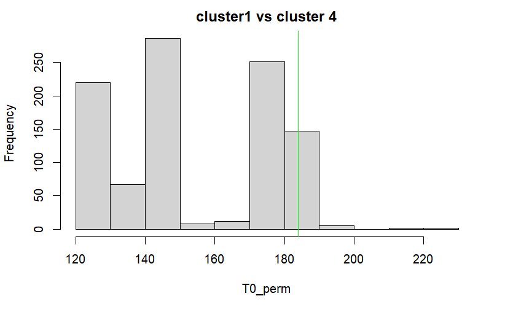

```r
pval = sum(T0_perm >= T0)/B
hist(T0_perm, main = "cluster1 vs cluster 4")
abline(v=T0,col='green')
```

```r
print(paste("pvalue for test cluster 2 vs cluster 4 is :", pval)) #
```

```
[1] "pvalue for test cluster 2 vs cluster 4 is : 0.097"
```

#Cluster 2-5

```r
x1_fd <- fd_colonylost[clus2,]
x2_fd <- fd_colonylost[clus5,]
medianx1 <- median2
medianx2 <- median5

datapooled=append_fData(x1_fd,x2_fd)

n=datapooled$N
n1=x1_fd$N
n2=x2_fd$N

meandiff = medianx1$values - medianx2$values
#plot(grid,meandiff,type = 'l')
T0=(sum(abs(meandiff)))
#And, Knowing that under H0 the two groups of curves are IID,
# my likelihood-invariant permutation scheme is of course label permutation, so:
B <- 1000
set.seed(2023)
T0_perm=numeric(B)

pb = progress::progress_bar$new(total = B,
                                format = " Processing [:bar] :percent eta: :eta")
for(b in 1:B){
  permutazione <- sample(n)
  datapooled_perm=datapooled[permutazione,]
  perm_1 = datapooled_perm[1:n1,]
  perm_2 = datapooled_perm[(n1+1):n,]
  #se funzionale
  meandiff_p =median_fData(perm_1,type='MBD')$values-median_fData(perm_2,type='MBD')$values
  T0_perm[b]=(sum(abs(meandiff_p))) #set
  pb$tick()
}
```

```
 Processing [>---------------------------]   3% eta:  6s
 Processing [>---------------------------]   4% eta:  6s
 Processing [>---------------------------]   5% eta:  6s
 Processing [=>--------------------------]   5% eta:  6s
 Processing [=>--------------------------]   6% eta:  6s
 Processing [=>--------------------------]   6% eta:  7s
 Processing [=>--------------------------]   6% eta:  6s
 Processing [=>--------------------------]   7% eta:  7s
 Processing [=>--------------------------]   7% eta:  6s
 Processing [=>--------------------------]   7% eta:  7s
 Processing [=>--------------------------]   8% eta:  7s
 Processing [=>--------------------------]   8% eta:  6s
 Processing [=>--------------------------]   8% eta:  7s
 Processing [=>--------------------------]   8% eta:  6s
 Processing [=>--------------------------]   8% eta:  7s
 Processing [=>--------------------------]   9% eta:  7s
 Processing [=>--------------------------]   9% eta:  6s
 Processing [==>-------------------------]   9% eta:  6s
 Processing [==>-------------------------]   9% eta:  7s
 Processing [==>-------------------------]   9% eta:  6s
 Processing [==>-------------------------]  10% eta:  6s
 Processing [==>-------------------------]  11% eta:  6s
 Processing [==>-------------------------]  12% eta:  6s
 Processing [===>------------------------]  12% eta:  6s
 Processing [===>------------------------]  13% eta:  6s
 Processing [===>------------------------]  14% eta:  6s
 Processing [===>------------------------]  15% eta:  6s
 Processing [===>------------------------]  16% eta:  6s
 Processing [====>-----------------------]  16% eta:  6s
 Processing [====>-----------------------]  17% eta:  6s
 Processing [====>-----------------------]  18% eta:  6s
 Processing [====>-----------------------]  19% eta:  6s
 Processing [====>-----------------------]  20% eta:  6s
 Processing [=====>----------------------]  20% eta:  6s
 Processing [=====>----------------------]  21% eta:  6s
 Processing [=====>----------------------]  22% eta:  6s
 Processing [=====>----------------------]  23% eta:  6s
 Processing [======>---------------------]  23% eta:  6s
 Processing [======>---------------------]  24% eta:  6s
 Processing [======>---------------------]  25% eta:  6s
```

[output cut: 87 more lines]

```
 Processing [========================>---]  91% eta:  1s
 Processing [=========================>--]  91% eta:  1s
 Processing [=========================>--]  92% eta:  1s
 Processing [=========================>--]  93% eta:  1s
 Processing [=========================>--]  94% eta:  1s
 Processing [=========================>--]  94% eta:  0s
 Processing [=========================>--]  95% eta:  0s
 Processing [==========================>-]  95% eta:  0s
 Processing [==========================>-]  96% eta:  0s
 Processing [==========================>-]  97% eta:  0s
 Processing [==========================>-]  98% eta:  0s
 Processing [===========================>]  98% eta:  0s
 Processing [===========================>]  99% eta:  0s
 Processing [===========================>] 100% eta:  0s
 Processing [============================] 100% eta:  0s
```

Let’s see the results:

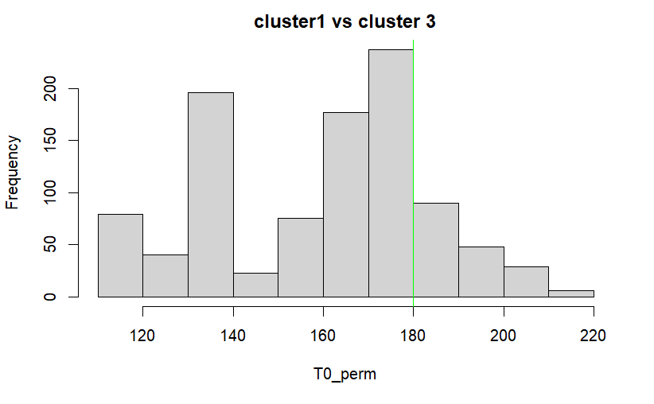

```r
pval = sum(T0_perm >= T0)/B
hist(T0_perm, main = "cluster1 vs cluster 3")
abline(v=T0,col='green')
```

```r
print(paste("pvalue for test cluster 2 vs cluster 5 is :", pval)) #
```

```
[1] "pvalue for test cluster 2 vs cluster 5 is : 0.227"
```

#Cluster 2-6

```r
x1_fd <- fd_colonylost[clus2,]
x2_fd <- fd_colonylost[clus6,]
medianx1 <- median2
medianx2 <- median6

datapooled=append_fData(x1_fd,x2_fd)

n=datapooled$N
n1=x1_fd$N
n2=x2_fd$N

meandiff = medianx1$values - medianx2$values
#plot(grid,meandiff,type = 'l')
T0=(sum(abs(meandiff)))
#And, Knowing that under H0 the two groups of curves are IID,
# my likelihood-invariant permutation scheme is of course label permutation, so:
B <- 1000
set.seed(2023)
T0_perm=numeric(B)

pb = progress::progress_bar$new(total = B,
                                format = " Processing [:bar] :percent eta: :eta")
for(b in 1:B){
  permutazione <- sample(n)
  datapooled_perm=datapooled[permutazione,]
  perm_1 = datapooled_perm[1:n1,]
  perm_2 = datapooled_perm[(n1+1):n,]
  #se funzionale
  meandiff_p =median_fData(perm_1,type='MBD')$values-median_fData(perm_2,type='MBD')$values
  T0_perm[b]=(sum(abs(meandiff_p))) #set
  pb$tick()
}
```

[output not shown]

[output cut: 76 more lines]

[output not shown]

Let’s see the results:

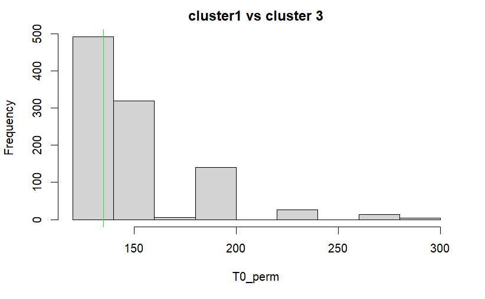

```r
pval = sum(T0_perm >= T0)/B
hist(T0_perm, main = "cluster1 vs cluster 3")
abline(v=T0,col='green')
```

```r
print(paste("pvalue for test cluster 2 vs cluster 6 is :", pval)) #
```

```
[1] "pvalue for test cluster 2 vs cluster 6 is : 0.713"
```

#Cluster 3-4

```r
x1_fd <- fd_colonylost[clus3,]
x2_fd <- fd_colonylost[clus4,]
medianx1 <- median3
medianx2 <- median4

datapooled=append_fData(x1_fd,x2_fd)

n=datapooled$N
n1=x1_fd$N
n2=x2_fd$N

meandiff = medianx1$values - medianx2$values
#plot(grid,meandiff,type = 'l')
T0=(sum(abs(meandiff)))
#And, Knowing that under H0 the two groups of curves are IID,
# my likelihood-invariant permutation scheme is of course label permutation, so:
B <- 1000
set.seed(2023)
T0_perm=numeric(B)

pb = progress::progress_bar$new(total = B,
                                format = " Processing [:bar] :percent eta: :eta")
for(b in 1:B){
  permutazione <- sample(n)
  datapooled_perm=datapooled[permutazione,]
  perm_1 = datapooled_perm[1:n1,]
  perm_2 = datapooled_perm[(n1+1):n,]
  #se funzionale
  meandiff_p =median_fData(perm_1,type='MBD')$values-median_fData(perm_2,type='MBD')$values
  T0_perm[b]=(sum(abs(meandiff_p))) #set
  pb$tick()
}
```

[output not shown]

[output cut: 80 more lines]

[output not shown]

Let’s see the results:

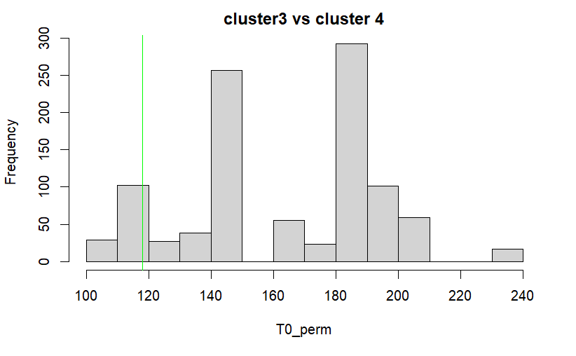

```r
pval = sum(T0_perm >= T0)/B
hist(T0_perm, main = "cluster3 vs cluster 4")
abline(v=T0,col='green')
```

```r
print(paste("pvalue for test cluster 2 vs cluster 3 is :", pval)) #
```

[output not shown]

#Cluster 3-5

```r
x1_fd <- fd_colonylost[clus3,]
x2_fd <- fd_colonylost[clus5,]
medianx1 <- median3
medianx2 <- median5

datapooled=append_fData(x1_fd,x2_fd)

n=datapooled$N
n1=x1_fd$N
n2=x2_fd$N

meandiff = medianx1$values - medianx2$values
#plot(grid,meandiff,type = 'l')
T0=(sum(abs(meandiff)))
#And, Knowing that under H0 the two groups of curves are IID,
# my likelihood-invariant permutation scheme is of course label permutation, so:
B <- 1000
set.seed(2023)
T0_perm=numeric(B)

pb = progress::progress_bar$new(total = B,
                                format = " Processing [:bar] :percent eta: :eta")
for(b in 1:B){
  permutazione <- sample(n)
  datapooled_perm=datapooled[permutazione,]
  perm_1 = datapooled_perm[1:n1,]
  perm_2 = datapooled_perm[(n1+1):n,]
  #se funzionale
  meandiff_p =median_fData(perm_1,type='MBD')$values-median_fData(perm_2,type='MBD')$values
  T0_perm[b]=(sum(abs(meandiff_p))) #set
  pb$tick()
}
```

[output not shown]

[output cut: 83 more lines]

[output not shown]

Let’s see the results:

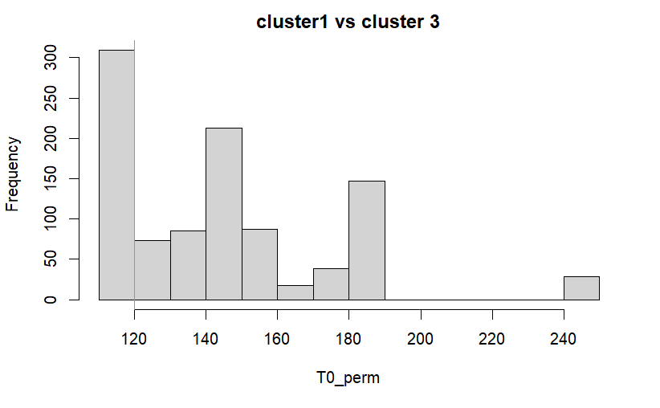

```r
pval = sum(T0_perm >= T0)/B
hist(T0_perm, main = "cluster1 vs cluster 3")
abline(v=T0,col='green')
```

```r
print(paste("pvalue for test cluster 3 vs cluster 5 is :", pval)) #
```

```
[1] "pvalue for test cluster 3 vs cluster 5 is : 0.848"
```

#Cluster 3-6

```r
x1_fd <- fd_colonylost[clus3,]
x2_fd <- fd_colonylost[clus6,]
medianx1 <- median3
medianx2 <- median6

datapooled=append_fData(x1_fd,x2_fd)

n=datapooled$N
n1=x1_fd$N
n2=x2_fd$N

meandiff = medianx1$values - medianx2$values
#plot(grid,meandiff,type = 'l')
T0=(sum(abs(meandiff)))
#And, Knowing that under H0 the two groups of curves are IID,
# my likelihood-invariant permutation scheme is of course label permutation, so:
B <- 1000
set.seed(2023)
T0_perm=numeric(B)

pb = progress::progress_bar$new(total = B,
                                format = " Processing [:bar] :percent eta: :eta")
for(b in 1:B){
  permutazione <- sample(n)
  datapooled_perm=datapooled[permutazione,]
  perm_1 = datapooled_perm[1:n1,]
  perm_2 = datapooled_perm[(n1+1):n,]
  #se funzionale
  meandiff_p =median_fData(perm_1,type='MBD')$values-median_fData(perm_2,type='MBD')$values
  T0_perm[b]=(sum(abs(meandiff_p))) #set
  pb$tick()
}
```

[output not shown]

[output cut: 75 more lines]

[output not shown]

Let’s see the results:

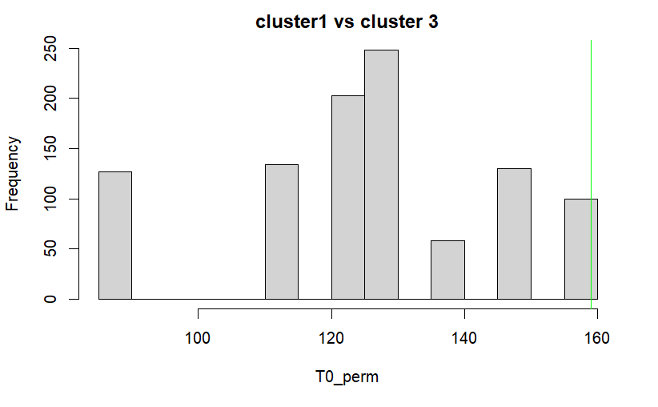

```r
pval = sum(T0_perm >= T0)/B
hist(T0_perm, main = "cluster1 vs cluster 3")
abline(v=T0,col='green')
```

```r
print(paste("pvalue for test cluster 2 vs cluster 3 is :", pval)) #
```

[output not shown]

#Cluster 4-5

```r
x1_fd <- fd_colonylost[clus4,]
x2_fd <- fd_colonylost[clus5,]
medianx1 <- median4
medianx2 <- median5

datapooled=append_fData(x1_fd,x2_fd)

n=datapooled$N
n1=x1_fd$N
n2=x2_fd$N

meandiff = medianx1$values - medianx2$values
#plot(grid,meandiff,type = 'l')
T0=(sum(abs(meandiff)))
#And, Knowing that under H0 the two groups of curves are IID,
# my likelihood-invariant permutation scheme is of course label permutation, so:
B <- 1000
set.seed(2023)
T0_perm=numeric(B)

pb = progress::progress_bar$new(total = B,
                                format = " Processing [:bar] :percent eta: :eta")
for(b in 1:B){
  permutazione <- sample(n)
  datapooled_perm=datapooled[permutazione,]
  perm_1 = datapooled_perm[1:n1,]
  perm_2 = datapooled_perm[(n1+1):n,]
  #se funzionale
  meandiff_p =median_fData(perm_1,type='MBD')$values-median_fData(perm_2,type='MBD')$values
  T0_perm[b]=(sum(abs(meandiff_p))) #set
  pb$tick()
}
```

[output not shown]

[output cut: 78 more lines]

[output not shown]

Let’s see the results:

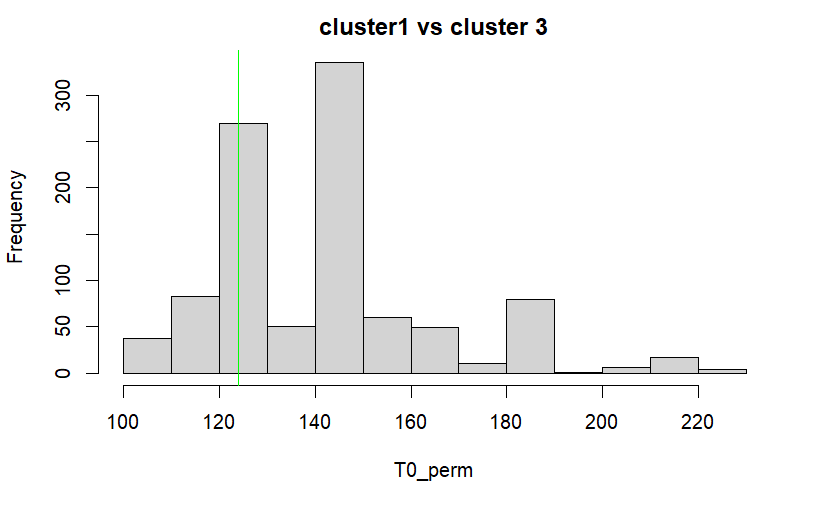

```r
pval = sum(T0_perm >= T0)/B
hist(T0_perm, main = "cluster1 vs cluster 3")
abline(v=T0,col='green')
```

```r
print(paste("pvalue for test cluster 4 vs cluster 5 is :", pval)) #
```

```
[1] "pvalue for test cluster 4 vs cluster 5 is : 0.859"
```

#Cluster 4-6

```r
x1_fd <- fd_colonylost[clus4,]
x2_fd <- fd_colonylost[clus6,]
medianx1 <- median4
medianx2 <- median6

datapooled=append_fData(x1_fd,x2_fd)

n=datapooled$N
n1=x1_fd$N
n2=x2_fd$N

meandiff = medianx1$values - medianx2$values
#plot(grid,meandiff,type = 'l')
T0=(sum(abs(meandiff)))
#And, Knowing that under H0 the two groups of curves are IID,
# my likelihood-invariant permutation scheme is of course label permutation, so:
B <- 1000
set.seed(2023)
T0_perm=numeric(B)

pb = progress::progress_bar$new(total = B,
                                format = " Processing [:bar] :percent eta: :eta")
for(b in 1:B){
  permutazione <- sample(n)
  datapooled_perm=datapooled[permutazione,]
  perm_1 = datapooled_perm[1:n1,]
  perm_2 = datapooled_perm[(n1+1):n,]
  #se funzionale
  meandiff_p =median_fData(perm_1,type='MBD')$values-median_fData(perm_2,type='MBD')$values
  T0_perm[b]=(sum(abs(meandiff_p))) #set
  pb$tick()
}
```

[output not shown]

[output cut: 76 more lines]

[output not shown]

Let’s see the results:

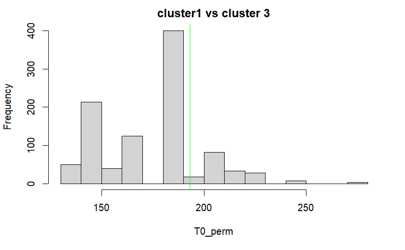

```r
pval = sum(T0_perm >= T0)/B
hist(T0_perm, main = "cluster1 vs cluster 3")
abline(v=T0,col='green')
```

```r
print(paste("pvalue for test cluster 4 vs cluster 6 is :", pval)) #
```

```
[1] "pvalue for test cluster 4 vs cluster 6 is : 0.171"
```

#Cluster 5-6

```r
x1_fd <- fd_colonylost[clus5,]
x2_fd <- fd_colonylost[clus6,]
medianx1 <- median4
medianx2 <- median6

datapooled=append_fData(x1_fd,x2_fd)

n=datapooled$N
n1=x1_fd$N
n2=x2_fd$N

meandiff = medianx1$values - medianx2$values
#plot(grid,meandiff,type = 'l')
T0=(sum(abs(meandiff)))
#And, Knowing that under H0 the two groups of curves are IID,
# my likelihood-invariant permutation scheme is of course label permutation, so:
B <- 1000
set.seed(2023)
T0_perm=numeric(B)

pb = progress::progress_bar$new(total = B,
                                format = " Processing [:bar] :percent eta: :eta")
for(b in 1:B){
  permutazione <- sample(n)
  datapooled_perm=datapooled[permutazione,]
  perm_1 = datapooled_perm[1:n1,]
  perm_2 = datapooled_perm[(n1+1):n,]
  #se funzionale
  meandiff_p =median_fData(perm_1,type='MBD')$values-median_fData(perm_2,type='MBD')$values
  T0_perm[b]=(sum(abs(meandiff_p))) #set
  pb$tick()
}
```

[output not shown]

[output cut: 86 more lines]

[output not shown]

Let’s see the results:

```r
pval = sum(T0_perm >= T0)/B
hist(T0_perm, main = "cluster1 vs cluster 3")
abline(v=T0,col='green')
print(paste("pvalue for test cluster 5 vs cluster 6 is :", pval)) #
```

[output not shown]